# ERP model

## Position Van Petten and Kutas

```r
write("vanpetten", stderr())
pos.df = subset(adultdata.df,  str_detect(adultdata.df$Condition,"(CONG|INCOH)")) # & tick < 10)

print(head(pos.df[pos.df$measure=="target",c("word","wordcat","Condition","Example","tick")])) # check
```

```
##         word wordcat Condition                                     Example
## 112035   man   NOUNA      CONG  man -s throw -ed the toy to the driver . .
## 112048    -s      PL      CONG  man -s throw -ed the toy to the driver . .
## 112061 throw   VERBD      CONG  man -s throw -ed the toy to the driver . .
## 112074   -ed      ED      CONG  man -s throw -ed the toy to the driver . .
## 112087   the     DET      CONG  man -s throw -ed the toy to the driver . .
## 112100   toy   NOUNI      CONG  man -s throw -ed the toy to the driver . .
##        tick
## 112035    1
## 112048    2
## 112061    3
## 112074    4
## 112087    5
## 112100    6
```

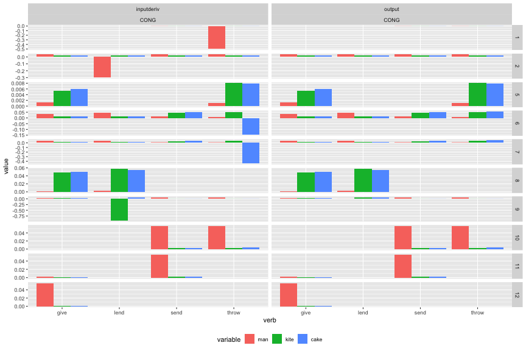

```r
postargword.df = subset(pos.df, layer %in% c("word") & measure %in% c("output",mainMeasure) & contfunc=="C" & wordcat != "VERBD" & Condition == "CONG")
postargword.df$verb = str_match(postargword.df$Example,"(give|throw|send|lend)")[,2]
meanbyword = aggregate(cbind(man,kite,cake) ~ tick + measure + verb + Condition,postargword.df, mean)
meanbywordlong= melt(meanbyword,id.var=1:4)

p1 = ggplot(meanbywordlong, aes(x=verb, y=value, fill = variable))
p1 = p1 + geom_bar(stat="identity",position="dodge")
#p1 = p1 + facet_wrap(~ measure + tick,scales = "free",ncol=4)
p1 = p1 + facet_grid( tick ~ measure + Condition,scales = "free_y")
p1 = p1 + theme(legend.position="bottom")
p1
```

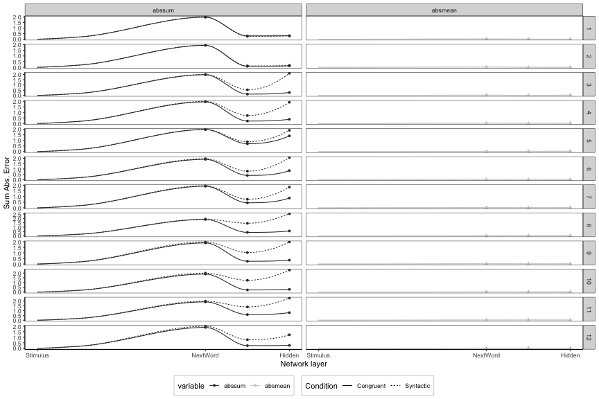

```r
# this is for creating ERP figure
nooutput = subset(pos.df, ! measure %in% layerNotERP)
end = which(names(nooutput)=="depth")-1
first = which(names(nooutput)=="none")
norawpos.df = nooutput[,-(first:end)] # remove word specific activations/error
norawpos.df$Condition = factor(norawpos.df$Condition,labels=c("Congruent","Syntactic"))

dvlen = length(names(norawpos.df))- which(names(norawpos.df)=="depth")
longnoraw= melt(norawpos.df,id.var=1:(length(norawpos.df)-dvlen)) # make long format

# add target layer for figure
longnoraw2 = subset(longnoraw, measure == mainMeasure & contfunc == "C") #& wordcat != "VERBD"
#longnoraw2$contfunc = paste(longnoraw2$tick,longnoraw2$contfunc)
#mapping = aes(x=depth, y=value, colour = Condition,linetype=Condition)
p1= drawERP(longnoraw2,"value","Condition","variable","tick", timesize=-1)
p1 = p1 + facet_grid(tick ~ variable ,scales = "free")
#p1 = p1 + facet_wrap( ~ tick+variable)
p1
```

```r
interactionText=""
# get example for table
tablesub = subset(norawpos.df,layer == "word" & measure == mainMeasure & tick == 2)
exampleTable = tablesub[1:4,c("Condition","Example")]
tabletext = kable(exampleTable,format="latex",row.names=FALSE)
print(exampleTable)
```

```
##        Condition                                            Example
## 112050 Congruent         man -s throw -ed the toy to the driver . .
## 112193 Syntactic         steak -s throw -ed the man to the kite . .
## 112752 Congruent  the father was lend -ing a sister the kite -s . .
## 112908 Syntactic   the ball was lend -ing a coffee the woman -s . .
```

```r
posinput  = subset(norawpos.df,measure == mainMeasure & layer %in% c("word",p600layer) & word != "." & contfunc=="C" & wordcat %in% c("NOUNA","NOUNI"))
#posinput = subset(posinput, !str_detect(Example,"-par") )

if (nlevels(adultdata.df$sub) > 4){ # do mixed with more than 9 subj
  print("run models")
  # our analysis uses this set

  posinput$dcoher = ifelse(posinput$Condition=="Congruent",1,0)
  posinput$ccoher = ifelse(posinput$Condition=="Congruent",0.5,-0.5)
  posinput$cword = ifelse(posinput$layer=="word",0.5,-0.5)
  posinput$ctick = posinput$tick - mean(posinput$tick)
  posinput$ccontent = ifelse(posinput$contfunc=="C",0.5,-0.5)
#& wordcat != "VERBD"
  posinputnoun = subset(posinput, layer == "word")
  randomeff = paste(" + (1 + dcoher*ctick |sub)")
  if (noslopes){ randomeff = " + (1 | sub)"}
  formu = as.formula(paste(dependMeasure,"~ ctick*dcoher",randomeff ))
  omnimodel = lmer(formu, posinputnoun,control=lmerControl(optimizer = "bobyqa",optCtrl=list(maxfun=50000)))
  print(summary(omnimodel))

  modellist = modelComparison(omnimodel) # create anova table by terms subtraction

  # create figure for paper
}
```

```
## [1] "run models"
## Linear mixed model fit by REML ['lmerMod']
## Formula: abssum ~ ctick * dcoher + (1 + dcoher * ctick | sub)
##    Data: posinputnoun
## Control: lmerControl(optimizer = "bobyqa", optCtrl = list(maxfun = 50000))
##
## REML criterion at convergence: -5296.3
##
## Scaled residuals:
##      Min       1Q   Median       3Q      Max
## -23.5576  -0.3104   0.0780   0.4200   2.4187
##
## Random effects:
##  Groups   Name         Variance  Std.Dev.  Corr
##  sub      (Intercept)  3.583e-05 0.0059860
##           dcoher       7.349e-06 0.0027109 -1.00
##           ctick        1.821e-06 0.0013493  1.00 -1.00
##           dcoher:ctick 1.933e-07 0.0004397 -1.00  1.00 -1.00
##  Residual              2.996e-03 0.0547353
## Number of obs: 1800, groups:  sub, 10
##
## Fixed effects:
##                Estimate Std. Error t value
## (Intercept)   1.9631757  0.0026291 746.719
## ctick         0.0027206  0.0007025   3.873
## dcoher       -0.0493966  0.0027189 -18.168
## ctick:dcoher -0.0095747  0.0008014 -11.948
##
## Correlation of Fixed Effects:
##             (Intr) ctick  dcoher
## ctick        0.437
## dcoher      -0.693 -0.192
## ctick:dcohr -0.125 -0.659  0.055
## [1] "remove . ~ . -  ctick:dcoher "
```

```
## refitting model(s) with ML (instead of REML)
```

```
## Data: posinputnoun
## Models:
## model2: abssum ~ ctick + dcoher + (1 + dcoher * ctick | sub)
## model: abssum ~ ctick * dcoher + (1 + dcoher * ctick | sub)
##        Df     AIC     BIC logLik deviance  Chisq Chi Df Pr(>Chisq)
## model2 14 -5281.8 -5204.9 2654.9  -5309.8
## model  15 -5313.0 -5230.6 2671.5  -5343.0 33.163      1  8.476e-09 ***
## ---
## Signif. codes:  0 '***' 0.001 '**' 0.01 '*' 0.05 '.' 0.1 ' ' 1
## [1] "########## Above comparison for  ctick:dcoher  *** "
## [1] "remove . ~ . -  dcoher "
```

```
## refitting model(s) with ML (instead of REML)
```

```
## Data: posinputnoun
## Models:
## model2: abssum ~ ctick + (1 + dcoher * ctick | sub)
## model: abssum ~ ctick + dcoher + (1 + dcoher * ctick | sub)
##        Df     AIC     BIC logLik deviance  Chisq Chi Df Pr(>Chisq)
## model2 13 -5275.0 -5203.5 2650.5  -5301.0
## model  14 -5281.8 -5204.9 2654.9  -5309.8 8.8597      1   0.002915 **
## ---
## Signif. codes:  0 '***' 0.001 '**' 0.01 '*' 0.05 '.' 0.1 ' ' 1
## [1] "########## Above comparison for  dcoher  *** "
## [1] "remove . ~ . -  ctick "
```

```
## refitting model(s) with ML (instead of REML)
```

```
## Data: posinputnoun
## Models:
## model2: abssum ~ (1 + dcoher * ctick | sub)
## model: abssum ~ ctick + (1 + dcoher * ctick | sub)
##        Df     AIC     BIC logLik deviance  Chisq Chi Df Pr(>Chisq)
## model2 12 -5273.4 -5207.5 2648.7  -5297.4
## model  13 -5275.0 -5203.5 2650.5  -5301.0 3.5591      1    0.05922 .
## ---
## Signif. codes:  0 '***' 0.001 '**' 0.01 '*' 0.05 '.' 0.1 ' ' 1
## [1] "########## Above comparison for  ctick "
```

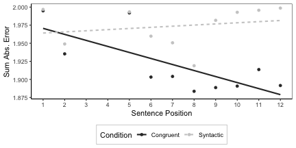

```r
# & wordcat != "VERBD"
  longnoraw2 = subset(posinput,  layer == "word" )
  form = as.formula(paste(dependMeasure," ~ tick + Condition",sep=""))
  mdf = aggregate(form, longnoraw2, mean)
  mapping = aes_string(x="tick", y=dependMeasure, colour = "Condition",linetype="Condition")
  p1 = ggplot(mdf,mapping=mapping)
  #p1 = p1 + geom_line() + geom_point()
  p1 = p1 + geom_point()
  p1 = p1 + stat_smooth(method="lm",se=F)
  p1 = p1 + scale_colour_grey()
#  p1 = p1 + scale_colour_brewer( palette="Set1")
  p1 = p1 + scale_x_continuous(breaks=1:12)
  p1 = p1 + theme_bw()
  p1 = p1 +theme(legend.background = element_rect(size=.4, color="grey80"))
  p1=p1 + theme(legend.position="bottom")+xlab("Sentence Position")+ylab("Sum Abs. Error")
  p1 = p1 + theme(panel.grid.major = element_blank(),
                  panel.grid.minor = element_blank(),
                  panel.background = element_blank(),
                  axis.line = element_line(colour = "black"))
  cong = str_split(exampleTable$Example[1]," ")[[1]]
  inco = str_split(exampleTable$Example[2]," ")[[1]]

coindf = data.frame(tick=rep(1:9,2),word=c(cong[2:10],inco[2:10]),Condition=rep(c("Congruent","Incoherent"),each=9),dependMeasure=rep(c(1.9,1.97),each=9))

#   p1=p1+geom_text(aes(x=tick, y= dependMeasure,label=word,colour = Condition),coindf,size=3)
p1
```

```r
  if (!noslopes){ # when doing final version, change noslopes to FALSE
    myggsave("img/vanpetten.png",width=figwidth,height=figheight) # control font size with height/width
  }
n4P6cor = computeN4P6correlation(posinput)
print(paste("N400/P600 correlation",n4P6cor))
```

```
## [1] "N400/P600 correlation -0.313495766048524"
```

CUT AND PASTE INTO LATEX DOC click in box and use right arrow to see whole text

```latex
Need stats to explain this

This is an example of the stimuli used in the model

\begin{tabular}{l|l}
\hline
Condition & Example\\
\hline
Congruent & man -s throw -ed the toy to the driver . .\\
\hline
Syntactic & steak -s throw -ed the man to the kite . .\\
\hline
Congruent & the father was lend -ing a sister the kite -s . .\\
\hline
Syntactic & the ball was lend -ing a coffee the woman -s . .\\
\hline
\end{tabular}
The maximal model for the data had random slopes  + (1 + dcoher*ctick |sub)

Mixed Model Results
no main effect of ctick ,$\beta$=0.0027, SE=7e-04, $\chi^2$(1)=3.56, p=0.059
a main effect of dcoher ,$\beta$=-0.049, SE=0.0027, $\chi^2$(1)=8.86, p=0.0029
@@ @@an interaction of ctick:dcoher ,$\beta$=-0.0096, SE=8e-04, $\chi^2$(1)=33.16, p$<$0.001
```

## AGREEMENT Hagoort et al 1993

```r
# This is Hagoort et al 1993
write("agree", stderr())
agree.df = subset(adultdata.df,  str_detect(Condition,"(PLUR|SING)") )
verbpos = which(agree.df$wordcat == "VERBT")
#verb.df = agree.df[verbpos,]
wordcatsamelen = which(agree.df$wordcat!=agree.df$wordcat[1])[1]-1  # same number of rows for each category
postverb.df = agree.df[verbpos + wordcatsamelen,] # position after verb
postverb.df=postverb.df[!is.na(postverb.df$Condition),]

cond = str_split_fixed(postverb.df$Condition,";",2)
postverb.df$Number = cond[,1]
postverb.df$Agreement = cond[,2]
postverb.df$Number = factor(postverb.df$Number,labels=c("Plural","Singular"))
postverb.df$Agreement = factor(postverb.df$Agreement,labels=c("Control","Violation"))
nc = length(postverb.df)
postverb.df = postverb.df[,c(nc-1,nc,1:(nc-2))]
xtabs(~ Agreement + Number ,postverb.df)
```

```
##            Number
## Agreement   Plural Singular
##   Control     3000     3000
##   Violation   3000     3000
```

```r
print(head(postverb.df[postverb.df$measure=="target",c("word","wordcat","Condition","Example","tick")])) # check
```

```
##        word wordcat Condition                              Example tick
## 112373    a     DET PLUR;CONT          the boy -s take a stick . .    5
## 112477  -ss      SS PLUR;VIOL      the boy -s take -ss a stick . .    5
## 112581  -ss      SS SING;CONT         the boy take -ss a stick . .    4
## 112685    a     DET SING;VIOL             the boy take a stick . .    4
## 115441 wine   NOUNI PLUR;CONT      the father -s taste wine -s . .    5
## 115545  -ss      SS PLUR;VIOL  the father -s taste -ss wine -s . .    5
```

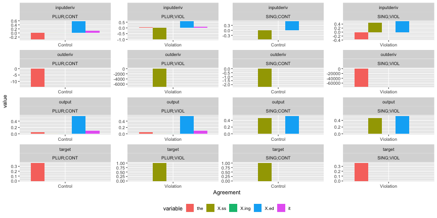

```r
showWordOutError("the,X.ss,X.ing,X.ed,it",c("Agreement","measure","Condition"),postverb.df)
```

```r
computeClozeERPCorr(postverb.df,dependMeasure,"hidden")
```

```
## [1] "Correlation output prediction and abssum error of hidden is -0.635099300781296"
```

```r
corrHiddenOutputInputDeriv(postverb.df,"Agreement","Number")
```

```
## Condition
##               ACTCONT               CATCONT               CATVIOL
##                     0                     0                     0
##                  CONG               GARDAMB                GARDSC
##                     0                     0                     0
##             HIGHCLOZE                 INCOH              LOWCLOZE
##                     0                     0                     0
##              PASSCONT             PLUR;CONT             PLUR;VIOL
##                     0                     8                     8
##               SEMATTR             SING;CONT             SING;VIOL
##                     0                     8                     8
##               STRONG    STRONGCONS;EXPECTED STRONGCONS;UNEXPECTED
##                     0                     0                     0
##               SUBCONT               SUBVIOL             TENSECONT
##                     0                     0                     0
##             TENSEVIOL             TEST-PRED           TEST-UNPRED
##                     0                     0                     0
##                  WEAK                 WEAK      WEAKCONS;EXPECTED
##                     0                     0                     0
##   WEAKCONS;UNEXPECTED             ́ZEROCLOZE
##                     0                     0
```

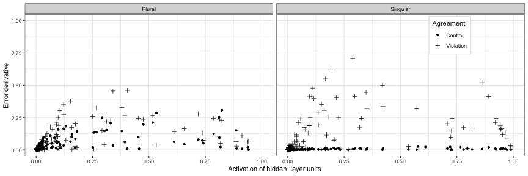

```
##   Number Agreement sub  epoch word wordcat contfunc
## 1 Plural   Control  s0 100000    a     DET        F
## 2 Plural   Control  s0 100000    a     DET        F
## 3 Plural   Control  s0 100000    a     DET        F
## 4 Plural   Control  s0 100000    a     DET        F
## 5 Plural   Control  s0 100000    a     DET        F
## 6 Plural   Control  s0 100000    a     DET        F
##                        Example Condition tick    layer    measure depth
## 1  the boy -s take a stick . . PLUR;CONT    5     word   outderiv     1
## 2  the boy -s take a stick . . PLUR;CONT    5     word inputderiv     1
## 3  the boy -s take a stick . . PLUR;CONT    5 compress   outderiv     2
## 4  the boy -s take a stick . . PLUR;CONT    5 compress inputderiv     2
## 5  the boy -s take a stick . . PLUR;CONT    5   hidden   outderiv     3
## 6  the boy -s take a stick . . PLUR;CONT    5   hidden inputderiv     3
##   variable      value
## 1   abssum  7.4703980
## 2   abssum  1.7322764
## 3   abssum 56.9887266
## 4   abssum  1.4021043
## 5   abssum 18.1684365
## 6   abssum  0.9772369
```

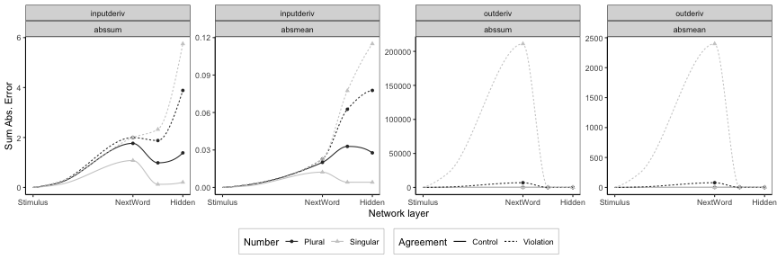

```r
# make erp figure with different measures
#mapping = aes(x=depth, y=value, colour = Number,linetype=Agreement)
#norawpostverbnotargout.df=removeWordsDrawERP(postverb.df,"value","Number","Agreement","variable",showFig=T)
norawpostverbnotargout.df=removeWordsDrawERP(postverb.df,"value","Agreement","Number","measure",iv5="variable",showFig=T)
```

```r
interactionText="NO TEXT"
modellist2 = list()
difflex = 0

# get example for table
agreeinputword = subset(norawpostverbnotargout.df,measure == mainMeasure  & layer == "word")
exampleTable = agreeinputword[1:4,c("Number","Agreement","Example")]
tabletext = kable(exampleTable,format="latex",row.names=FALSE)
print(exampleTable)
```

```
##          Number Agreement                          Example
## 112375   Plural   Control      the boy -s take a stick . .
## 112479   Plural Violation  the boy -s take -ss a stick . .
## 112583 Singular   Control     the boy take -ss a stick . .
## 112687 Singular Violation         the boy take a stick . .
```

```r
agreeinput  = subset(norawpostverbnotargout.df,measure == mainMeasure & layer %in% c("word",p600layer) )

if (nlevels(adultdata.df$sub) > 4){ # do mixed with more than 9 subj

  agreeinput$cplural = ifelse(agreeinput$Number=="Plural",0.5,-0.5)
  agreeinput$cviolation = ifelse(agreeinput$Agreement=="Violation",0.5,-0.5)
  agreeinput$cp6layer = ifelse(agreeinput$layer==p600layer,0.5,-0.5)

  # this is the main mixed model with centered variables
    randomeff = paste(" + (1 + cviolation*cp6layer |sub)")  #Agreement * layer
      if (noslopes){ randomeff = " + (1 | sub)"}
  formu = as.formula(paste(dependMeasure,"~ cviolation*cp6layer",randomeff))
  omnimodel = lmer(formu, agreeinput,control=lmerControl(optimizer = "bobyqa",optCtrl=list(maxfun=50000)))
  print(summary(omnimodel))
  modellist2 = modelComparison(omnimodel) # create anova table
  # this model is for posthocs
  formu2 = as.formula(paste(dependMeasure,"~ Agreement*layer",randomeff))
  omnimodelFactor = lmer(formu2, agreeinput)
  #print(summary(omnimodelFactor))
  model.lsmobj <- lsmeans(omnimodelFactor, ~ Agreement | layer)
  posthocs = summary(as.glht(pairs(model.lsmobj)))
  print(posthocs)
  interactionText = printInteraction(posthocs)

  difflex = abs(posthocs$`layer = word`$test$coefficients[[1]])
}
```

```
## Linear mixed model fit by REML ['lmerMod']
## Formula: abssum ~ cviolation * cp6layer + (1 + cviolation * cp6layer |
##     sub)
##    Data: agreeinput
## Control: lmerControl(optimizer = "bobyqa", optCtrl = list(maxfun = 50000))
##
## REML criterion at convergence: 7411.3
##
## Scaled residuals:
##     Min      1Q  Median      3Q     Max
## -3.8373 -0.3443  0.0001  0.2544  5.9185
##
## Random effects:
##  Groups   Name                Variance Std.Dev. Corr
##  sub      (Intercept)         0.2806   0.5297
##           cviolation          0.4496   0.6705   0.88
##           cp6layer            0.9643   0.9820   1.00 0.90
##           cviolation:cp6layer 2.1000   1.4491   0.92 0.99 0.94
##  Residual                     1.2446   1.1156
## Number of obs: 2400, groups:  sub, 10
##
## Fixed effects:
##                     Estimate Std. Error t value
## (Intercept)           2.2591     0.1691  13.363
## cviolation            2.2993     0.2169  10.602
## cp6layer              1.0973     0.3139   3.496
## cviolation:cp6layer   3.4465     0.4672   7.377
##
## Correlation of Fixed Effects:
##             (Intr) cviltn cp6lyr
## cviolation  0.853
## cp6layer    0.980  0.869
## cvltn:cp6ly 0.897  0.954  0.910
## [1] "remove . ~ . -  cviolation:cp6layer "
```

```
## refitting model(s) with ML (instead of REML)
```

```
## Data: agreeinput
## Models:
## model2: abssum ~ cviolation + cp6layer + (1 + cviolation * cp6layer |
## model2:     sub)
## model: abssum ~ cviolation * cp6layer + (1 + cviolation * cp6layer |
## model:     sub)
##        Df    AIC    BIC  logLik deviance  Chisq Chi Df Pr(>Chisq)
## model2 14 7448.2 7529.1 -3710.1   7420.2
## model  15 7430.7 7517.4 -3700.3   7400.7 19.509      1  1.001e-05 ***
## ---
## Signif. codes:  0 '***' 0.001 '**' 0.01 '*' 0.05 '.' 0.1 ' ' 1
## [1] "########## Above comparison for  cviolation:cp6layer  *** "
## [1] "remove . ~ . -  cp6layer "
```

```
## refitting model(s) with ML (instead of REML)
```

```
## Data: agreeinput
## Models:
## model2: abssum ~ cviolation + (1 + cviolation * cp6layer | sub)
## model: abssum ~ cviolation + cp6layer + (1 + cviolation * cp6layer |
## model:     sub)
##        Df    AIC    BIC  logLik deviance  Chisq Chi Df Pr(>Chisq)
## model2 13 7452.9 7528.1 -3713.5   7426.9
## model  14 7448.2 7529.1 -3710.1   7420.2 6.7507      1   0.009371 **
## ---
## Signif. codes:  0 '***' 0.001 '**' 0.01 '*' 0.05 '.' 0.1 ' ' 1
## [1] "########## Above comparison for  cp6layer  *** "
## [1] "remove . ~ . -  cviolation "
```

```
## refitting model(s) with ML (instead of REML)
```

```
## Data: agreeinput
## Models:
## model2: abssum ~ (1 + cviolation * cp6layer | sub)
## model: abssum ~ cviolation + (1 + cviolation * cp6layer | sub)
##        Df    AIC    BIC  logLik deviance Chisq Chi Df Pr(>Chisq)
## model2 12 7458.8 7528.2 -3717.4   7434.8
## model  13 7452.9 7528.1 -3713.5   7426.9 7.879      1   0.005001 **
## ---
## Signif. codes:  0 '***' 0.001 '**' 0.01 '*' 0.05 '.' 0.1 ' ' 1
## [1] "########## Above comparison for  cviolation  *** "
```

```
## Note: df set to 9
```

```
## $`layer = word`
##
##   Simultaneous Tests for General Linear Hypotheses
##
## Linear Hypotheses:
##                          Estimate Std. Error t value Pr(>|t|)
## Control - Violation == 0 -0.57607    0.07023  -8.203 1.81e-05 ***
## ---
## Signif. codes:  0 '***' 0.001 '**' 0.01 '*' 0.05 '.' 0.1 ' ' 1
## (Adjusted p values reported -- single-step method)
##
##
## $`layer = hidden`
##
##   Simultaneous Tests for General Linear Hypotheses
##
## Linear Hypotheses:
##                          Estimate Std. Error t value Pr(>|t|)
## Control - Violation == 0  -4.0225     0.4453  -9.034 8.28e-06 ***
## ---
## Signif. codes:  0 '***' 0.001 '**' 0.01 '*' 0.05 '.' 0.1 ' ' 1
## (Adjusted p values reported -- single-step method)
```

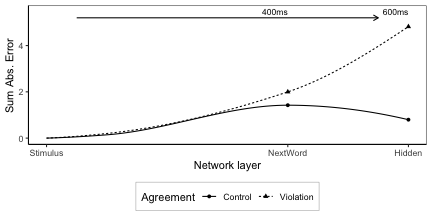

```r
  # figure for paper
# mapping = aes_string(x="depth", y=dependMeasure, colour = "Agreement",linetype="Agreement")
  drawERP(agreeinput,dependMeasure,"Agreement",  span=1, timeline.y=5.2)
```

```r
  if (!noslopes){ # when doing final version, change noslopes to FALSE
    myggsave("img/agree.png",width=figwidth,height=figheight)
  }
n4P6cor = computeN4P6correlation(agreeinput)
print(paste("N400/P600 correlation",n4P6cor))
```

```
## [1] "N400/P600 correlation -0.635099307875991"
```

```r
n4P6cor = computeN4P6correlation2(agreeinput,"Control","Violation",cond="Agreement")
print(paste("N400/P600 correlation",n4P6cor))
```

```
## [1] "N400/P600 correlation -0.347896923432525"
```

CUT AND PASTE INTO LATEX DOC click in box and use right arrow to see whole text

```latex
The model received active transitive input with singular subjects 75\% of the time and plural subjects 25\% of the time.

This is an example of the stimuli used in the model.


\begin{tabular}{l|l|l}
\hline
Number & Agreement & Example\\
\hline
Plural & Control & the boy -s take a stick . .\\
\hline
Plural & Violation & the boy -s take -ss a stick . .\\
\hline
Singular & Control & the boy take -ss a stick . .\\
\hline
Singular & Violation & the boy take a stick . .\\
\hline
\end{tabular}
The maximal model for the data had random slopes  + (1 + cviolation*cp6layer |sub)

Mixed Model Results
a main effect of cviolation ,$\beta$=2.3, SE=0.22, $\chi^2$(1)=7.88, p=0.005
a main effect of cp6layer ,$\beta$=1.1, SE=0.31, $\chi^2$(1)=6.75, p=0.0094
@@an interaction of cviolation:cp6layer ,$\beta$=3.4, SE=0.47, $\chi^2$(1)=19.51, p$<$0.001

Posthoc tests for  layer = word
 @@Posthoc: There was a significant difference for Control - Violation, diff = 0.5761, t(9)=8.2, p$<$0.001
Posthoc tests for  layer = hidden
 @@Posthoc: There was a significant difference for Control - Violation, diff = 4.0225, t(9)=9.03, p$<$0.001
ratio  Control - Violation   6.982  rev  0.143
```

## Tense Allen et al. (2003)

```r
write("tense", stderr())
tense.df = subset(adultdata.df,  str_detect(Condition,"(TENSECONT|TENSEVIOL)") )
tense.df$Condition = factor(tense.df$Condition,labels=c("Control","Violation"))
verbpos = which(tense.df$wordcat == "VERBT")
wordcatsamelen = which(tense.df$wordcat!=tense.df$wordcat[1])[1]-1
verb.df = tense.df[verbpos,] #  verb
postverb.df = tense.df[verbpos + wordcatsamelen,] # position after verb
postverb.df=postverb.df[!is.na(postverb.df$Condition),]

print(head(postverb.df[postverb.df$measure=="target",c("word","wordcat","Condition","Example","tick")]))
```

```
##        word wordcat Condition
## 139166  the     DET   Control
## 139283  -ed      ED Violation
## 147252  the     DET   Control
## 147369  -ed      ED Violation
## 155546  the     DET   Control
## 155676  -ed      ED Violation
##                                              Example tick
## 139166           a father will drink the beer -s . .    5
## 139283       a father will drink -ed the beer -s . .    5
## 147252         the driver will taste the wine -s . .    5
## 147369     the driver will taste -ed the wine -s . .    5
## 155546      the driver -s will taste the beer -s . .    6
## 155676  the driver -s will taste -ed the beer -s . .    6
```

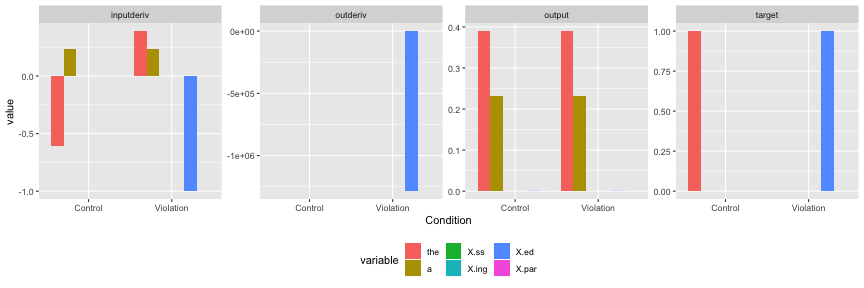

```r
showWordOutError("the,a,X.ss,X.ing,X.ed,X.par",c("Condition","measure"),postverb.df)
```

```r
corrHiddenOutputInputDeriv(postverb.df,"Condition")
```

```
## Condition
##   Control Violation
##         8         8
```

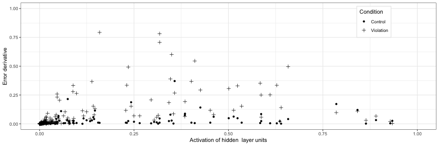

```r
myggsave("img/actderivtense.png",width=6,height=6)
```

```r
# make erp figure with different measures
norawpostverbnotargout.df=removeWordsDrawERP(postverb.df,"value","Condition")
```

```
##   sub  epoch word wordcat contfunc                              Example
## 1  s0 100000  the     DET        F  a father will drink the beer -s . .
## 2  s0 100000  the     DET        F  a father will drink the beer -s . .
## 3  s0 100000  the     DET        F  a father will drink the beer -s . .
## 4  s0 100000  the     DET        F  a father will drink the beer -s . .
## 5  s0 100000  the     DET        F  a father will drink the beer -s . .
## 6  s0 100000  the     DET        F  a father will drink the beer -s . .
##   Condition tick    layer    measure depth variable     value
## 1   Control    5     word   outderiv     1   abssum 1.2117450
## 2   Control    5     word inputderiv     1   abssum 0.3494872
## 3   Control    5 compress   outderiv     2   abssum 5.7298633
## 4   Control    5 compress inputderiv     2   abssum 0.2838988
## 5   Control    5   hidden   outderiv     3   abssum 3.8026026
## 6   Control    5   hidden inputderiv     3   abssum 0.2746235
```

```r
interactionText="NO TEXT"
modellist2 = list()
# get example for table
tenseexampleword = subset(norawpostverbnotargout.df,measure == mainMeasure  & layer == "word")
exampleTable = tenseexampleword[1:2,c("Condition","Example")]
tabletext = kable(exampleTable,format="latex",row.names=FALSE)
print(exampleTable)
```

```
##        Condition                                  Example
## 139168   Control      a father will drink the beer -s . .
## 139285 Violation  a father will drink -ed the beer -s . .
```

```r
 tenseinput  = subset(norawpostverbnotargout.df,measure == mainMeasure & layer %in% c("word",p600layer) )

if (nlevels(adultdata.df$sub) > 4){ # do mixed with more than 9 subj

  tenseinput$cviolation = ifelse(tenseinput$Condition=="Violation",0.5,-0.5) # one against two
  tenseinput$cp600layer = ifelse(tenseinput$layer==p600layer,0.5,-0.5)

  # this is the main mixed model with centered variables
  randomeff = paste(" + (1 +  cviolation*cp600layer |sub)")  # Condition*layer
  if (noslopes){ randomeff = " + (1 | sub)"}
  formu = as.formula(paste(dependMeasure,"~ cviolation*cp600layer",randomeff))
  omnimodel = lmer(formu, tenseinput,control=lmerControl(optimizer = "bobyqa",optCtrl=list(maxfun=50000)))
  print(summary(omnimodel))
  modellist2 = modelComparison(omnimodel) # create anova table

  # this model is for posthocs
  formu2 = as.formula(paste(dependMeasure,"~ Condition*layer",randomeff))
  omnimodelFactor = lmer(formu2, tenseinput)
  #print(summary(omnimodelFactor))
  model.lsmobj <- lsmeans(omnimodelFactor, ~ Condition | layer)
  posthocs = summary(as.glht(pairs(model.lsmobj)))
  print(posthocs)
  interactionText = printInteraction(posthocs)
  difflex = difflex + abs(posthocs$`layer = word`$test$coefficients[[1]])

}
```

```
## Linear mixed model fit by REML ['lmerMod']
## Formula:
## abssum ~ cviolation * cp600layer + (1 + cviolation * cp600layer |
##     sub)
##    Data: tenseinput
## Control: lmerControl(optimizer = "bobyqa", optCtrl = list(maxfun = 50000))
##
## REML criterion at convergence: 3374
##
## Scaled residuals:
##     Min      1Q  Median      3Q     Max
## -4.5670 -0.5457  0.0004  0.5447  9.3367
##
## Random effects:
##  Groups   Name                  Variance Std.Dev. Corr
##  sub      (Intercept)           0.4298   0.6556
##           cviolation            0.9295   0.9641   0.73
##           cp600layer            1.4997   1.2246   1.00 0.77
##           cviolation:cp600layer 3.8627   1.9654   0.81 0.99 0.84
##  Residual                       0.9090   0.9534
## Number of obs: 1200, groups:  sub, 10
##
## Fixed effects:
##                       Estimate Std. Error t value
## (Intercept)             2.9088     0.2091  13.909
## cviolation              3.5446     0.3098  11.442
## cp600layer              2.5985     0.3911   6.643
## cviolation:cp600layer   5.5315     0.6312   8.764
##
## Correlation of Fixed Effects:
##             (Intr) cviltn cp600l
## cviolation  0.709
## cp600layer  0.979  0.750
## cvltn:cp600 0.786  0.962  0.821
## [1] "remove . ~ . -  cviolation:cp600layer "
```

```
## refitting model(s) with ML (instead of REML)
```

```
## Data: tenseinput
## Models:
## model2: abssum ~ cviolation + cp600layer + (1 + cviolation * cp600layer |
## model2:     sub)
## model: abssum ~ cviolation * cp600layer + (1 + cviolation * cp600layer |
## model:     sub)
##        Df    AIC    BIC  logLik deviance  Chisq Chi Df Pr(>Chisq)
## model2 14 3416.5 3487.8 -1694.3   3388.5
## model  15 3396.0 3472.4 -1683.0   3366.0 22.534      1  2.064e-06 ***
## ---
## Signif. codes:  0 '***' 0.001 '**' 0.01 '*' 0.05 '.' 0.1 ' ' 1
## [1] "########## Above comparison for  cviolation:cp600layer  *** "
## [1] "remove . ~ . -  cp600layer "
```

```
## refitting model(s) with ML (instead of REML)
```

```
## Data: tenseinput
## Models:
## model2: abssum ~ cviolation + (1 + cviolation * cp600layer | sub)
## model: abssum ~ cviolation + cp600layer + (1 + cviolation * cp600layer |
## model:     sub)
##        Df    AIC    BIC  logLik deviance  Chisq Chi Df Pr(>Chisq)
## model2 13 3414.6 3480.8 -1694.3   3388.6
## model  14 3416.5 3487.8 -1694.3   3388.5 0.1049      1      0.746
## [1] "########## Above comparison for  cp600layer "
## [1] "remove . ~ . -  cviolation "
```

```
## refitting model(s) with ML (instead of REML)
```

```
## Data: tenseinput
## Models:
## model2: abssum ~ (1 + cviolation * cp600layer | sub)
## model: abssum ~ cviolation + (1 + cviolation * cp600layer | sub)
##        Df    AIC    BIC  logLik deviance  Chisq Chi Df Pr(>Chisq)
## model2 12 3422.6 3483.6 -1699.3   3398.6
## model  13 3414.6 3480.8 -1694.3   3388.6 9.9171      1   0.001638 **
## ---
## Signif. codes:  0 '***' 0.001 '**' 0.01 '*' 0.05 '.' 0.1 ' ' 1
## [1] "########## Above comparison for  cviolation  *** "
```

```
## Note: df set to 9
```

```
## $`layer = word`
##
##   Simultaneous Tests for General Linear Hypotheses
##
## Linear Hypotheses:
##                          Estimate Std. Error t value Pr(>|t|)
## Control - Violation == 0 -0.77888    0.08669  -8.984 8.66e-06 ***
## ---
## Signif. codes:  0 '***' 0.001 '**' 0.01 '*' 0.05 '.' 0.1 ' ' 1
## (Adjusted p values reported -- single-step method)
##
##
## $`layer = hidden`
##
##   Simultaneous Tests for General Linear Hypotheses
##
## Linear Hypotheses:
##                          Estimate Std. Error t value Pr(>|t|)
## Control - Violation == 0  -6.3104     0.6194  -10.19 3.06e-06 ***
## ---
## Signif. codes:  0 '***' 0.001 '**' 0.01 '*' 0.05 '.' 0.1 ' ' 1
## (Adjusted p values reported -- single-step method)
```

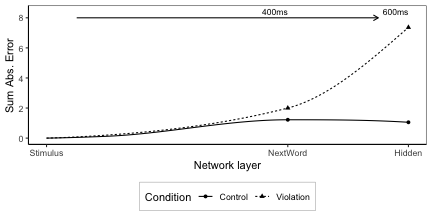

```r
  # figure for paper
 # mapping = aes_string(x="depth", y=dependMeasure, colour = "Condition",linetype="Condition")
  drawERP(tenseinput,dependMeasure,"Condition",  timeline.y=8,span=.8)
```

```r
  if (!noslopes){ # when doing final version, change noslopes to FALSE
    myggsave("img/tense.png",width=figwidth,height=figheight)
  }

n4P6cor = computeN4P6correlation(tenseinput)
print(paste("N400/P600 correlation",n4P6cor))
```

```
## [1] "N400/P600 correlation -0.626156749789801"
```

```r
n4P6cor = computeN4P6correlation2(tenseinput,"Control","Violation")
print(paste("N400/P600 correlation",n4P6cor))
```

```
## [1] "N400/P600 correlation -0.419532545097064"
```

CUT AND PASTE INTO LATEX DOC click in box and use right arrow to see whole text

```latex
This is an example of the stimuli used in the model.


\begin{tabular}{l|l}
\hline
Condition & Example\\
\hline
Control & a father will drink the beer -s . .\\
\hline
Violation & a father will drink -ed the beer -s . .\\
\hline
\end{tabular}
The maximal model for the data had random slopes  + (1 +  cviolation*cp600layer |sub)

Mixed Model Results
a main effect of cviolation ,$\beta$=3.5, SE=0.31, $\chi^2$(1)=9.92, p=0.0016
no main effect of cp600layer ,$\beta$=2.6, SE=0.39, $\chi^2$(1)=0.1, p=0.746
@@an interaction of cviolation:cp600layer ,$\beta$=5.5, SE=0.63, $\chi^2$(1)=22.53, p$<$0.001

Posthoc tests for  layer = word
 @@Posthoc: There was a significant difference for Control - Violation, diff = 0.7789, t(9)=8.98, p$<$0.001
Posthoc tests for  layer = hidden
 @@Posthoc: There was a significant difference for Control - Violation, diff = 6.3104, t(9)=10.19, p$<$0.001
ratio  Control - Violation   8.102  rev  0.123
```

## WORDCAT (Wassenaar and Hagoort, 2005)

```r
write("wordcat", stderr())
cat.df = subset(adultdata.df,  str_detect(Condition,"(CATCONT|CATVIOL)") )
cat.df$Condition=factor(cat.df$Condition,labels=c("Control","Violation"))
verbpos = which(cat.df$wordcat == "VERBI")
wordcatsamelen = which(cat.df$wordcat!=cat.df$wordcat[1])[1]-1
verb.df = cat.df[verbpos,] #  verb
postverb.df = cat.df[verbpos + wordcatsamelen,] # position after verb
postverb.df=postverb.df[!is.na(postverb.df$Condition),]

print(head(postverb.df[postverb.df$measure=="target",c("word","wordcat","Condition","Example","tick")])) # check
```

```
##        word wordcat Condition                                    Example
## 118340   -s      PL   Control   the grandma was take -ing the nap -s . .
## 118470  -ed      ED Violation  the grandma was take -ing the nap -ed . .
## 152387   -s      PL   Control           the girl take -ed the nap -s . .
## 152504  -ed      ED Violation          the girl take -ed the nap -ed . .
## 165465   -s      PL   Control     a teacher was take -ing the nap -s . .
## 165595  -ed      ED Violation    a teacher was take -ing the nap -ed . .
##        tick
## 118340    8
## 118470    8
## 152387    7
## 152504    7
## 165465    8
## 165595    8
```

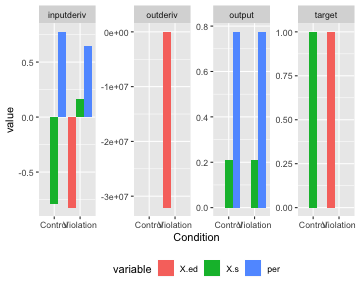

```r
showWordOutError("X.ed,X.s,per",c("Condition","measure"),postverb.df)
```

```r
corrHiddenOutputInputDeriv(postverb.df,"Condition")
```

```
## Condition
##   Control Violation
##         8         8
```

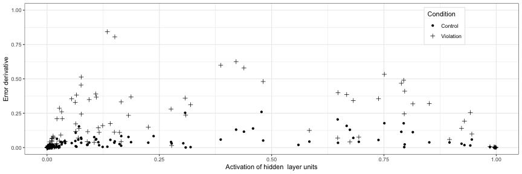

```r
#mapping = aes(x=depth, y=value, colour = Condition,linetype=Condition)
norawpostverbnotargout.df=removeWordsDrawERP(postverb.df,"value", "Condition")
```

```
##   sub  epoch word wordcat contfunc
## 1  s0 100000   -s      PL        F
## 2  s0 100000   -s      PL        F
## 3  s0 100000   -s      PL        F
## 4  s0 100000   -s      PL        F
## 5  s0 100000   -s      PL        F
## 6  s0 100000   -s      PL        F
##                                     Example Condition tick    layer
## 1  the grandma was take -ing the nap -s . .   Control    8     word
## 2  the grandma was take -ing the nap -s . .   Control    8     word
## 3  the grandma was take -ing the nap -s . .   Control    8 compress
## 4  the grandma was take -ing the nap -s . .   Control    8 compress
## 5  the grandma was take -ing the nap -s . .   Control    8   hidden
## 6  the grandma was take -ing the nap -s . .   Control    8   hidden
##      measure depth variable      value
## 1   outderiv     1   abssum  6.2936400
## 2 inputderiv     1   abssum  1.6822183
## 3   outderiv     2   abssum 63.0345795
## 4 inputderiv     2   abssum  0.7655548
## 5   outderiv     3   abssum 24.1052016
## 6 inputderiv     3   abssum  1.2524126
```

```r
interactionText="NO TEXT"
modellist2 = list()

# get example for table
catwordexample = subset(norawpostverbnotargout.df,measure == mainMeasure  & layer == "word")
exampleTable = catwordexample[1:4,c("Condition","Example")]
tabletext = kable(exampleTable,format="latex",row.names=FALSE)
print(exampleTable)
```

```
##        Condition                                    Example
## 118342   Control   the grandma was take -ing the nap -s . .
## 118472 Violation  the grandma was take -ing the nap -ed . .
## 152389   Control           the girl take -ed the nap -s . .
## 152506 Violation          the girl take -ed the nap -ed . .
```

```r
catinput  = subset(norawpostverbnotargout.df,measure == mainMeasure & layer %in% c("word",p600layer) )

if (nlevels(adultdata.df$sub) > 4){ # do mixed with more than 9 subj

  catinput$cviolation = ifelse(catinput$Condition=="Violation",0.5,-0.5) # one against two
  catinput$cp600layer = ifelse(catinput$layer==p600layer,0.5,-0.5)

  # this is the main mixed model with centered variables
  randomeff = paste(" + (1 + Condition * layer |sub)")
    if (noslopes){ randomeff = " + (1 | sub)" }
  formu = as.formula(paste(dependMeasure,"~ cviolation*cp600layer",randomeff))
  omnimodel = lmer(formu, catinput,control=lmerControl(optimizer = "bobyqa",optCtrl=list(maxfun=50000)))
  print(summary(omnimodel))
  modellist2 = modelComparison(omnimodel) # create anova table

  # this model is for posthocs
  formu2 = as.formula(paste(dependMeasure,"~ Condition*layer",randomeff))
  omnimodelFactor = lmer(formu2, catinput)
  #print(summary(omnimodelFactor))
  model.lsmobj <- lsmeans(omnimodelFactor, ~ Condition | layer)
  posthocs = summary(as.glht(pairs(model.lsmobj)))
  print(posthocs)
  interactionText = printInteraction(posthocs)
  difflex = difflex + abs(posthocs$`layer = word`$test$coefficients[[1]])

}
```

```
## Linear mixed model fit by REML ['lmerMod']
## Formula: abssum ~ cviolation * cp600layer + (1 + Condition * layer | sub)
##    Data: catinput
## Control: lmerControl(optimizer = "bobyqa", optCtrl = list(maxfun = 50000))
##
## REML criterion at convergence: 3198.3
##
## Scaled residuals:
##     Min      1Q  Median      3Q     Max
## -5.9333 -0.2611 -0.0010  0.1601  6.2477
##
## Random effects:
##  Groups   Name                           Variance Std.Dev. Corr
##  sub      (Intercept)                    0.03168  0.1780
##           ConditionViolation             0.39445  0.6280    0.05
##           layerhidden                    0.48029  0.6930    0.81  0.32
##           ConditionViolation:layerhidden 3.06953  1.7520   -0.18  0.29
##  Residual                                0.76678  0.8757
##
##
##
##
##   0.27
##
## Number of obs: 1200, groups:  sub, 10
##
## Fixed effects:
##                       Estimate Std. Error t value
## (Intercept)             2.0689     0.2751   7.519
## cviolation              1.2334     0.3881   3.178
## cp600layer              0.9069     0.4006   2.264
## cviolation:cp600layer   2.3415     0.5632   4.158
##
## Correlation of Fixed Effects:
##             (Intr) cviltn cp600l
## cviolation  0.814
## cp600layer  0.916  0.791
## cvltn:cp600 0.669  0.848  0.827
## [1] "remove . ~ . -  cviolation:cp600layer "
```

```
## refitting model(s) with ML (instead of REML)
```

```
## Data: catinput
## Models:
## model2: abssum ~ cviolation + cp600layer + (1 + Condition * layer | sub)
## model: abssum ~ cviolation * cp600layer + (1 + Condition * layer | sub)
##        Df    AIC    BIC  logLik deviance  Chisq Chi Df Pr(>Chisq)
## model2 14 3231.3 3302.6 -1601.7   3203.3
## model  15 3222.6 3298.9 -1596.3   3192.6 10.718      1   0.001061 **
## ---
## Signif. codes:  0 '***' 0.001 '**' 0.01 '*' 0.05 '.' 0.1 ' ' 1
## [1] "########## Above comparison for  cviolation:cp600layer  *** "
## [1] "remove . ~ . -  cp600layer "
```

```
## refitting model(s) with ML (instead of REML)
```

```
## Data: catinput
## Models:
## model2: abssum ~ cviolation + (1 + Condition * layer | sub)
## model: abssum ~ cviolation + cp600layer + (1 + Condition * layer | sub)
##        Df    AIC    BIC  logLik deviance  Chisq Chi Df Pr(>Chisq)
## model2 13 3230.8 3297.0 -1602.4   3204.8
## model  14 3231.3 3302.6 -1601.7   3203.3 1.5408      1     0.2145
## [1] "########## Above comparison for  cp600layer "
## [1] "remove . ~ . -  cviolation "
```

```
## refitting model(s) with ML (instead of REML)
```

```
## Data: catinput
## Models:
## model2: abssum ~ (1 + Condition * layer | sub)
## model: abssum ~ cviolation + (1 + Condition * layer | sub)
##        Df    AIC    BIC  logLik deviance Chisq Chi Df Pr(>Chisq)
## model2 12 3228.8 3289.9 -1602.4   3204.8
## model  13 3230.8 3297.0 -1602.4   3204.8 2e-04      1     0.9877
## [1] "########## Above comparison for  cviolation "
```

```
## Note: df set to 9
```

```
## $`layer = word`
##
##   Simultaneous Tests for General Linear Hypotheses
##
## Linear Hypotheses:
##                          Estimate Std. Error t value Pr(>|t|)
## Control - Violation == 0 -0.06268    0.21108  -0.297    0.773
## (Adjusted p values reported -- single-step method)
##
##
## $`layer = hidden`
##
##   Simultaneous Tests for General Linear Hypotheses
##
## Linear Hypotheses:
##                          Estimate Std. Error t value Pr(>|t|)
## Control - Violation == 0  -2.4042     0.6444  -3.731  0.00469 **
## ---
## Signif. codes:  0 '***' 0.001 '**' 0.01 '*' 0.05 '.' 0.1 ' ' 1
## (Adjusted p values reported -- single-step method)
```

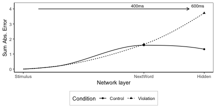

```r
  # figure for paper
#  mapping = aes_string(x="depth", y=dependMeasure, colour = "Condition",linetype="Condition")
  drawERP(catinput,dependMeasure,"Condition", timeline.y=4,span=0.8)
```

```r
  if (!noslopes){ # when doing final version, change noslopes to FALSE??n
    myggsave("img/cat.png",width=figwidth,height=figheight)
  }

n4P6cor = computeN4P6correlation(catinput)
print(paste("N400/P600 correlation",n4P6cor))
```

```
## [1] "N400/P600 correlation -0.53217912711318"
```

```r
n4P6cor = computeN4P6correlation2(catinput,"Control","Violation")
print(paste("N400/P600 correlation",n4P6cor))
```

```
## [1] "N400/P600 correlation -0.549173339243751"
```

CUT AND PASTE INTO LATEX DOC click in box and use right arrow to see whole text

```latex
This is an example of the stimuli used in the model.


\begin{tabular}{l|l}
\hline
Condition & Example\\
\hline
Control & the grandma was take -ing the nap -s . .\\
\hline
Violation & the grandma was take -ing the nap -ed . .\\
\hline
Control & the girl take -ed the nap -s . .\\
\hline
Violation & the girl take -ed the nap -ed . .\\
\hline
\end{tabular}
The maximal model for the data had random slopes  + (1 + Condition * layer |sub)

Mixed Model Results
no main effect of cviolation ,$\beta$=1.2, SE=0.39, $\chi^2$(1)=0, p=0.988
no main effect of cp600layer ,$\beta$=0.91, SE=0.4, $\chi^2$(1)=1.54, p=0.214
@@an interaction of cviolation:cp600layer ,$\beta$=2.3, SE=0.56, $\chi^2$(1)=10.72, p=0.0011

Posthoc tests for  layer = word
 @@Posthoc: There was no difference for Control - Violation, p=0.7733
Posthoc tests for  layer = hidden
 @@Posthoc: There was a significant difference for Control - Violation, diff = 2.4042, t(9)=3.73, p=0.0047
ratio  Control - Violation   38.344  rev  0.026
```

## SUBCAT Osterhout and Holcomb (1992)

```r
write("subcat", stderr())
sub.df = subset(adultdata.df,  str_detect(Condition,"(SUBCONT|SUBVIOL)") )
sub.df$Condition=factor(sub.df$Condition,labels=c("Control","Violation"))
preppos = which(sub.df$word %in% c("near","by"))
prep.df = sub.df[preppos,] #  verb

print(head(prep.df[prep.df$measure=="target",c("word","wordcat","Condition","Example","tick")])) # check
```

```
##        word wordcat Condition                                   Example
## 114284 near    PREP   Control     a sister is nap -ing near the boy . .
## 114414 near    PREP Violation    a sister is take -ing near the boy . .
## 116143   by      BY   Control           the uncle -s walk by tea -s . .
## 116260   by      BY Violation          the uncle -s drink by tea -s . .
## 117677   by      BY   Control  a grandma jump -ed by the brother -s . .
## 117807   by      BY Violation   a grandma sip -ed by the brother -s . .
##        tick
## 114284    6
## 114414    6
## 116143    5
## 116260    5
## 117677    5
## 117807    5
```

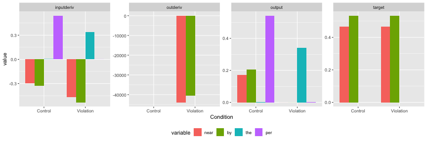

```r
showWordOutError("near,by,the,per",c("Condition","measure"),prep.df)
```

```r
corrHiddenOutputInputDeriv(prep.df,"Condition")
```

```
## Condition
##   Control Violation
##         8         8
```

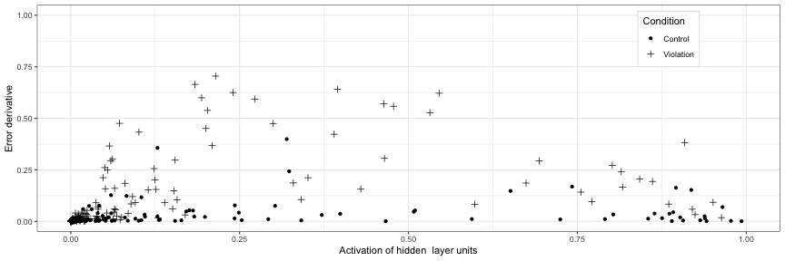

```r
#mapping = aes(x=depth, y=value, colour = Condition,linetype=Condition)
norawprepnotargout.df=removeWordsDrawERP(prep.df,"value","Condition")
```

```
##   sub  epoch word wordcat contfunc                                Example
## 1  s0 100000 near    PREP        F  a sister is nap -ing near the boy . .
## 2  s0 100000 near    PREP        F  a sister is nap -ing near the boy . .
## 3  s0 100000 near    PREP        F  a sister is nap -ing near the boy . .
## 4  s0 100000 near    PREP        F  a sister is nap -ing near the boy . .
## 5  s0 100000 near    PREP        F  a sister is nap -ing near the boy . .
## 6  s0 100000 near    PREP        F  a sister is nap -ing near the boy . .
##   Condition tick    layer    measure depth variable      value
## 1   Control    6     word   outderiv     1   abssum  8.7414080
## 2   Control    6     word inputderiv     1   abssum  1.7712038
## 3   Control    6 compress   outderiv     2   abssum 20.6027973
## 4   Control    6 compress inputderiv     2   abssum  0.4111479
## 5   Control    6   hidden   outderiv     3   abssum  8.2239300
## 6   Control    6   hidden inputderiv     3   abssum  0.5146847
```

```r
interactionText="NO TEXT"
modellist2 = list()

# get example for table
catwordexample = subset(norawprepnotargout.df,measure == mainMeasure  & layer == "word")
exampleTable = catwordexample[1:4,c("Condition","Example")]
tabletext = kable(exampleTable,format="latex",row.names=FALSE)
print(exampleTable)
```

```
##        Condition                                 Example
## 114286   Control   a sister is nap -ing near the boy . .
## 114416 Violation  a sister is take -ing near the boy . .
## 116145   Control         the uncle -s walk by tea -s . .
## 116262 Violation        the uncle -s drink by tea -s . .
```

```r
subinput  = subset(norawprepnotargout.df,measure == mainMeasure & layer %in% c("word",p600layer) )

if (nlevels(adultdata.df$sub) > 4){ # do mixed with more than 9 subj

  subinput$cviolation = ifelse(subinput$Condition=="Violation",0.5,-0.5) # one against two
  subinput$cp600layer = ifelse(subinput$layer==p600layer,0.5,-0.5)

  # this is the main mixed model with centered variables
  randomeff = paste(" + (1 + cviolation*cp600layer |sub)")
    if (noslopes){ randomeff = " + (1 | sub)"}
  formu = as.formula(paste(dependMeasure,"~ cviolation*cp600layer",randomeff))
  omnimodel = lmer(formu, subinput,control=lmerControl(optimizer = "bobyqa",optCtrl=list(maxfun=50000)))
  print(summary(omnimodel))
  modellist2 = modelComparison(omnimodel) # create anova table

  # this model is for posthocs
  formu2 = as.formula(paste(dependMeasure,"~ Condition*layer",randomeff))
  omnimodelFactor = lmer(formu2, subinput)
  #print(summary(omnimodelFactor))
  model.lsmobj <- lsmeans(omnimodelFactor, ~ Condition | layer)
  posthocs = summary(as.glht(pairs(model.lsmobj)))
  print(posthocs)
  interactionText = printInteraction(posthocs)
    difflex = difflex + abs(posthocs$`layer = word`$test$coefficients[[1]])

}
```

```
## Linear mixed model fit by REML ['lmerMod']
## Formula:
## abssum ~ cviolation * cp600layer + (1 + cviolation * cp600layer |
##     sub)
##    Data: subinput
## Control: lmerControl(optimizer = "bobyqa", optCtrl = list(maxfun = 50000))
##
## REML criterion at convergence: 3627.7
##
## Scaled residuals:
##     Min      1Q  Median      3Q     Max
## -3.2327 -0.3512  0.0002  0.1081  7.7900
##
## Random effects:
##  Groups   Name                  Variance Std.Dev. Corr
##  sub      (Intercept)           0.1307   0.3615
##           cviolation            0.6082   0.7798   0.94
##           cp600layer            0.4659   0.6826   1.00 0.94
##           cviolation:cp600layer 2.6521   1.6285   0.95 1.00 0.95
##  Residual                       1.1486   1.0717
## Number of obs: 1200, groups:  sub, 10
##
## Fixed effects:
##                       Estimate Std. Error t value
## (Intercept)             2.3365     0.1184  19.731
## cviolation              1.8520     0.2543   7.284
## cp600layer              1.0476     0.2245   4.666
## cviolation:cp600layer   2.9569     0.5296   5.583
##
## Correlation of Fixed Effects:
##             (Intr) cviltn cp600l
## cviolation  0.879
## cp600layer  0.928  0.881
## cvltn:cp600 0.891  0.943  0.892
## [1] "remove . ~ . -  cviolation:cp600layer "
```

```
## refitting model(s) with ML (instead of REML)
```

```
## Data: subinput
## Models:
## model2: abssum ~ cviolation + cp600layer + (1 + cviolation * cp600layer |
## model2:     sub)
## model: abssum ~ cviolation * cp600layer + (1 + cviolation * cp600layer |
## model:     sub)
##        Df    AIC    BIC  logLik deviance  Chisq Chi Df Pr(>Chisq)
## model2 14 3660.6 3731.9 -1816.3   3632.6
## model  15 3647.7 3724.0 -1808.8   3617.7 14.942      1  0.0001109 ***
## ---
## Signif. codes:  0 '***' 0.001 '**' 0.01 '*' 0.05 '.' 0.1 ' ' 1
## [1] "########## Above comparison for  cviolation:cp600layer  *** "
## [1] "remove . ~ . -  cp600layer "
```

```
## refitting model(s) with ML (instead of REML)
```

```
## Data: subinput
## Models:
## model2: abssum ~ cviolation + (1 + cviolation * cp600layer | sub)
## model: abssum ~ cviolation + cp600layer + (1 + cviolation * cp600layer |
## model:     sub)
##        Df    AIC    BIC  logLik deviance Chisq Chi Df Pr(>Chisq)
## model2 13 3658.8 3724.9 -1816.4   3632.8
## model  14 3660.6 3731.9 -1816.3   3632.6 0.115      1     0.7346
## [1] "########## Above comparison for  cp600layer "
## [1] "remove . ~ . -  cviolation "
```

```
## refitting model(s) with ML (instead of REML)
```

```
## Data: subinput
## Models:
## model2: abssum ~ (1 + cviolation * cp600layer | sub)
## model: abssum ~ cviolation + (1 + cviolation * cp600layer | sub)
##        Df    AIC    BIC  logLik deviance  Chisq Chi Df Pr(>Chisq)
## model2 12 3664.4 3725.4 -1820.2   3640.4
## model  13 3658.8 3724.9 -1816.4   3632.8 7.6001      1   0.005837 **
## ---
## Signif. codes:  0 '***' 0.001 '**' 0.01 '*' 0.05 '.' 0.1 ' ' 1
## [1] "########## Above comparison for  cviolation  *** "
```

```
## Note: df set to 9
```

```
## $`layer = word`
##
##   Simultaneous Tests for General Linear Hypotheses
##
## Linear Hypotheses:
##                          Estimate Std. Error t value Pr(>|t|)
## Control - Violation == 0 -0.37355    0.08854  -4.219  0.00224 **
## ---
## Signif. codes:  0 '***' 0.001 '**' 0.01 '*' 0.05 '.' 0.1 ' ' 1
## (Adjusted p values reported -- single-step method)
##
##
## $`layer = hidden`
##
##   Simultaneous Tests for General Linear Hypotheses
##
## Linear Hypotheses:
##                          Estimate Std. Error t value Pr(>|t|)
## Control - Violation == 0  -3.3304     0.5116   -6.51  0.00011 ***
## ---
## Signif. codes:  0 '***' 0.001 '**' 0.01 '*' 0.05 '.' 0.1 ' ' 1
## (Adjusted p values reported -- single-step method)
```

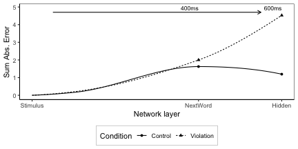

```r
  # figure for paper
    #mapping = aes_string(x="depth", y=dependMeasure, colour = "Condition",linetype="Condition")
  drawERP(subinput,dependMeasure,"Condition", timeline.y=4.7)
```

```r
  if (!noslopes){ # when doing final version, change noslopes to FALSE
    myggsave("img/subjcat.png",width=figwidth,height=figheight)
  }

n4P6cor = computeN4P6correlation(subinput)
print(paste("N400/P600 correlation",n4P6cor))
```

```
## [1] "N400/P600 correlation -0.635890912765104"
```

```r
n4P6cor = computeN4P6correlation2(subinput,"Control","Violation")
print(paste("N400/P600 correlation",n4P6cor))
```

```
## [1] "N400/P600 correlation -0.189705337541494"
```

CUT AND PASTE INTO LATEX DOC click in box and use right arrow to see whole text

```latex
This is an example of the stimuli used in the model.


\begin{tabular}{l|l}
\hline
Condition & Example\\
\hline
Control & a sister is nap -ing near the boy . .\\
\hline
Violation & a sister is take -ing near the boy . .\\
\hline
Control & the uncle -s walk by tea -s . .\\
\hline
Violation & the uncle -s drink by tea -s . .\\
\hline
\end{tabular}
The maximal model for the data had random slopes  + (1 + cviolation*cp600layer |sub)

Mixed Model Results
a main effect of cviolation ,$\beta$=1.9, SE=0.25, $\chi^2$(1)=7.6, p=0.0058
no main effect of cp600layer ,$\beta$=1, SE=0.22, $\chi^2$(1)=0.11, p=0.735
@@an interaction of cviolation:cp600layer ,$\beta$=3, SE=0.53, $\chi^2$(1)=14.94, p$<$0.001

Posthoc tests for  layer = word
 @@Posthoc: There was a significant difference for Control - Violation, diff = 0.3735, t(9)=4.22, p=0.0022
Posthoc tests for  layer = hidden
 @@Posthoc: There was a significant difference for Control - Violation, diff = 3.3304, t(9)=6.51, p$<$0.001
ratio  Control - Violation   8.917  rev  0.112
```

## GARDEN PATH

```r
write("garden", stderr())
garden.df = subset(adultdata.df,  str_detect(Condition,"(GARDSC|GARDAMB)") & tick > 4 )
garden.df$Condition=factor(garden.df$Condition,labels=c("Unambiguous","Ambiguous"),levels=c("GARDSC","GARDAMB"))
garden.df$tarword = str_match(garden.df$Example,"(believe|know)(.*?) (the|a) ([A-z]+)( -s)* ([A-z.]+)*")[,7]
garden.df$strlen = sapply(gregexpr("[^ ]+", garden.df$Example), function(x) sum(x > 0))
gardenpos = which(garden.df$word == garden.df$tarword)
gardentar.df = garden.df[gardenpos,] #  verb
gardentar.df= subset(gardentar.df,strlen != tick)
gardentar.df$strlen = NULL
gardentar.df$tarword = NULL

print(head(gardentar.df[gardentar.df$measure=="target",c("word","wordcat","Condition","Example","tick")])) # check
```

```
##        word wordcat   Condition
## 135110  run   VERBI Unambiguous
## 135240  run   VERBI   Ambiguous
## 150502  nap   VERBI Unambiguous
## 150632  nap   VERBI   Ambiguous
## 152998 walk   VERBI Unambiguous
## 153128 walk   VERBI   Ambiguous
##                                                   Example tick
## 135110  the driver believe -ed that the uncle run -ss . .    8
## 135240       the driver believe -ed the uncle run -ss . .    7
## 150502         man -s will know that the girl nap -ss . .    8
## 150632              man -s will know the girl nap -ss . .    7
## 152998    a grandpa know -ed that the sister walk -ss . .    8
## 153128         a grandpa know -ed the sister walk -ss . .    7
```

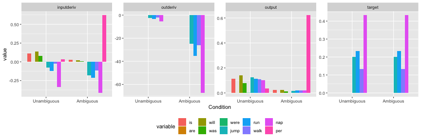

```r
showWordOutError("is,are,will,was,were,jump,run,walk,nap,per",c("Condition","measure"),gardentar.df)
```

```r
corrHiddenOutputInputDeriv(gardentar.df,"Condition")
```

```
## Condition
## Unambiguous   Ambiguous
##           8           8
```

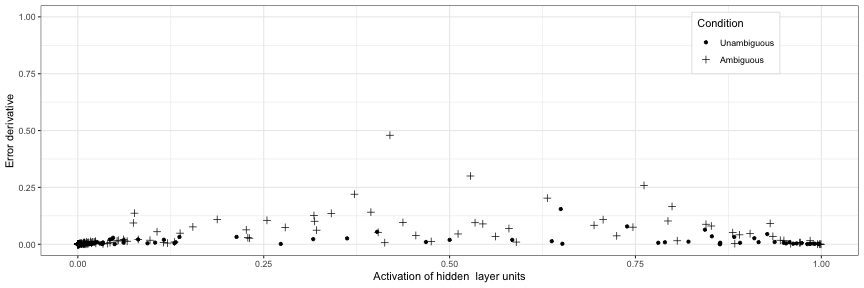

```r
#mapping = aes(x=depth, y=value, colour = Condition,linetype=Condition)
norawgardennotargout.df=removeWordsDrawERP(gardentar.df,"value","Condition")
```

```
##   sub  epoch word wordcat contfunc
## 1  s0 100000  run   VERBI        C
## 2  s0 100000  run   VERBI        C
## 3  s0 100000  run   VERBI        C
## 4  s0 100000  run   VERBI        C
## 5  s0 100000  run   VERBI        C
## 6  s0 100000  run   VERBI        C
##                                              Example   Condition tick
## 1  the driver believe -ed that the uncle run -ss . . Unambiguous    8
## 2  the driver believe -ed that the uncle run -ss . . Unambiguous    8
## 3  the driver believe -ed that the uncle run -ss . . Unambiguous    8
## 4  the driver believe -ed that the uncle run -ss . . Unambiguous    8
## 5  the driver believe -ed that the uncle run -ss . . Unambiguous    8
## 6  the driver believe -ed that the uncle run -ss . . Unambiguous    8
##      layer    measure depth variable      value
## 1     word   outderiv     1   abssum  4.0180600
## 2     word inputderiv     1   abssum  1.5022473
## 3 compress   outderiv     2   abssum 18.6331062
## 4 compress inputderiv     2   abssum  0.2655750
## 5   hidden   outderiv     3   abssum  6.6314658
## 6   hidden inputderiv     3   abssum  0.1725179
```

```r
interactionText="NO TEXT"
modellist2 = list()

# get example for table
gardenexample = subset(norawgardennotargout.df,measure == mainMeasure  & layer == "word")
exampleTable = gardenexample[1:6,c("Condition","Example")]
tabletext = kable(exampleTable,format="latex",row.names=FALSE)
print(exampleTable)
```

```
##          Condition                                            Example
## 135112 Unambiguous  the driver believe -ed that the uncle run -ss . .
## 135242   Ambiguous       the driver believe -ed the uncle run -ss . .
## 150504 Unambiguous         man -s will know that the girl nap -ss . .
## 150634   Ambiguous              man -s will know the girl nap -ss . .
## 153000 Unambiguous    a grandpa know -ed that the sister walk -ss . .
## 153130   Ambiguous         a grandpa know -ed the sister walk -ss . .
```

```r
gardeninput  = subset(norawgardennotargout.df,measure == mainMeasure & layer %in% c("word",p600layer) )

if (nlevels(adultdata.df$sub) > 4){ # do mixed with more than 9 subj
  gardeninput$cviolation = ifelse(gardeninput$Condition=="Ambiguous",0.5,-0.5) # one against two
  gardeninput$cp600layer = ifelse(gardeninput$layer==p600layer,0.5,-0.5)

  # this is the main mixed model with centered variables
  randomeff = paste(" + (1+ cviolation*cp600layer |sub)") # Condition * layer
    if (noslopes){ randomeff = " + (1 | sub)"}
    print(paste("************        RandomEffect ->",randomeff))
  formu = as.formula(paste(dependMeasure,"~ cviolation*cp600layer",randomeff))
  omnimodel = lmer(formu, gardeninput,control=lmerControl(optimizer = "bobyqa",optCtrl=list(maxfun=50000)))
  print(summary(omnimodel))
    modellist2 = modelComparison(omnimodel) # create anova table

  # this model is for posthocs
  formu2 = as.formula(paste(dependMeasure,"~ Condition*layer",randomeff))
  omnimodelFactor = lmer(formu2, gardeninput)
  #print(summary(omnimodelFactor))
  model.lsmobj <- lsmeans(omnimodelFactor, ~ Condition | layer)
  posthocs = summary(as.glht(pairs(model.lsmobj)))
  print(posthocs)
  interactionText = printInteraction(posthocs)
  difflex = difflex + abs(posthocs$`layer = word`$test$coefficients[[1]])

}
```

```
## [1] "************        RandomEffect ->  + (1+ cviolation*cp600layer |sub)"
## Linear mixed model fit by REML ['lmerMod']
## Formula:
## abssum ~ cviolation * cp600layer + (1 + cviolation * cp600layer |
##     sub)
##    Data: gardeninput
## Control: lmerControl(optimizer = "bobyqa", optCtrl = list(maxfun = 50000))
##
## REML criterion at convergence: 1964.6
##
## Scaled residuals:
##     Min      1Q  Median      3Q     Max
## -4.6090 -0.2296 -0.0007  0.1306  9.0168
##
## Random effects:
##  Groups   Name                  Variance Std.Dev. Corr
##  sub      (Intercept)           0.1041   0.3227
##           cviolation            0.2872   0.5359   0.84
##           cp600layer            0.3863   0.6215   1.00 0.82
##           cviolation:cp600layer 1.2470   1.1167   0.83 1.00 0.81
##  Residual                       0.2805   0.5296
## Number of obs: 1200, groups:  sub, 10
##
## Fixed effects:
##                       Estimate Std. Error t value
## (Intercept)             1.6311     0.1032  15.809
## cviolation              0.8070     0.1722   4.686
## cp600layer             -0.4814     0.1989  -2.420
## cviolation:cp600layer   1.2523     0.3584   3.494
##
## Correlation of Fixed Effects:
##             (Intr) cviltn cp600l
## cviolation  0.817
## cp600layer  0.977  0.802
## cvltn:cp600 0.806  0.969  0.790
## [1] "remove . ~ . -  cviolation:cp600layer "
```

```
## refitting model(s) with ML (instead of REML)
```

```
## Data: gardeninput
## Models:
## model2: abssum ~ cviolation + cp600layer + (1 + cviolation * cp600layer |
## model2:     sub)
## model: abssum ~ cviolation * cp600layer + (1 + cviolation * cp600layer |
## model:     sub)
##        Df    AIC    BIC  logLik deviance  Chisq Chi Df Pr(>Chisq)
## model2 14 1988.1 2059.3 -980.05   1960.1
## model  15 1981.5 2057.9 -975.76   1951.5 8.5649      1   0.003427 **
## ---
## Signif. codes:  0 '***' 0.001 '**' 0.01 '*' 0.05 '.' 0.1 ' ' 1
## [1] "########## Above comparison for  cviolation:cp600layer  *** "
## [1] "remove . ~ . -  cp600layer "
```

```
## refitting model(s) with ML (instead of REML)
```

```
## Data: gardeninput
## Models:
## model2: abssum ~ cviolation + (1 + cviolation * cp600layer | sub)
## model: abssum ~ cviolation + cp600layer + (1 + cviolation * cp600layer |
## model:     sub)
##        Df    AIC    BIC  logLik deviance  Chisq Chi Df Pr(>Chisq)
## model2 13 2000.8 2067.0 -987.40   1974.8
## model  14 1988.1 2059.3 -980.05   1960.1 14.706      1  0.0001257 ***
## ---
## Signif. codes:  0 '***' 0.001 '**' 0.01 '*' 0.05 '.' 0.1 ' ' 1
## [1] "########## Above comparison for  cp600layer  *** "
## [1] "remove . ~ . -  cviolation "
```

```
## refitting model(s) with ML (instead of REML)
```

```
## Data: gardeninput
## Models:
## model2: abssum ~ (1 + cviolation * cp600layer | sub)
## model: abssum ~ cviolation + (1 + cviolation * cp600layer | sub)
##        Df    AIC    BIC  logLik deviance  Chisq Chi Df Pr(>Chisq)
## model2 12 2003.9 2064.9 -989.94   1979.9
## model  13 2000.8 2067.0 -987.40   1974.8 5.0748      1    0.02428 *
## ---
## Signif. codes:  0 '***' 0.001 '**' 0.01 '*' 0.05 '.' 0.1 ' ' 1
## [1] "########## Above comparison for  cviolation  *** "
```

```
## Note: df set to 9
```

```
## $`layer = word`
##
##   Simultaneous Tests for General Linear Hypotheses
##
## Linear Hypotheses:
##                              Estimate Std. Error t value Pr(>|t|)
## Unambiguous - Ambiguous == 0 -0.18085    0.04402  -4.109  0.00264 **
## ---
## Signif. codes:  0 '***' 0.001 '**' 0.01 '*' 0.05 '.' 0.1 ' ' 1
## (Adjusted p values reported -- single-step method)
##
##
## $`layer = hidden`
##
##   Simultaneous Tests for General Linear Hypotheses
##
## Linear Hypotheses:
##                              Estimate Std. Error t value Pr(>|t|)
## Unambiguous - Ambiguous == 0  -1.4331     0.3487   -4.11  0.00264 **
## ---
## Signif. codes:  0 '***' 0.001 '**' 0.01 '*' 0.05 '.' 0.1 ' ' 1
## (Adjusted p values reported -- single-step method)
```

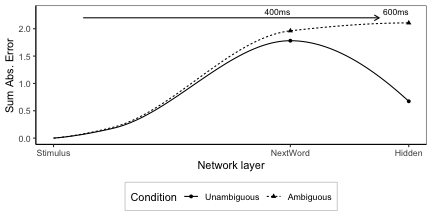

```r
  # figure for paper
#    mapping = aes_string(x="depth", y=dependMeasure, colour = "Condition",linetype="Condition")
  drawERP(gardeninput,dependMeasure, "Condition", timeline.y=2.2)
```

```r
  if (!noslopes){ # when doing final version, change noslopes to FALSE
    myggsave("img/garden.png",width=figwidth,height=figheight)
  }

n4P6cor = computeN4P6correlation(gardeninput)
print(paste("N400/P600 correlation",n4P6cor))
```

```
## [1] "N400/P600 correlation -0.490790299638552"
```

```r
n4P6cor = computeN4P6correlation2(gardeninput,"Unambiguous","Ambiguous")
print(paste("N400/P600 correlation",n4P6cor))
```

```
## [1] "N400/P600 correlation 0.0201289893837347"
```

CUT AND PASTE INTO LATEX DOC click in box and use right arrow to see whole text

```latex
UPDATE THIS

This is an example of the stimuli used in the model.


\begin{tabular}{l|l}
\hline
Condition & Example\\
\hline
Unambiguous & the driver believe -ed that the uncle run -ss . .\\
\hline
Ambiguous & the driver believe -ed the uncle run -ss . .\\
\hline
Unambiguous & man -s will know that the girl nap -ss . .\\
\hline
Ambiguous & man -s will know the girl nap -ss . .\\
\hline
Unambiguous & a grandpa know -ed that the sister walk -ss . .\\
\hline
Ambiguous & a grandpa know -ed the sister walk -ss . .\\
\hline
\end{tabular}
The maximal model for the data had random slopes  + (1+ cviolation*cp600layer |sub)

Mixed Model Results
a main effect of cviolation ,$\beta$=0.81, SE=0.17, $\chi^2$(1)=5.07, p=0.024
a main effect of cp600layer ,$\beta$=-0.48, SE=0.2, $\chi^2$(1)=14.71, p$<$0.001
@@an interaction of cviolation:cp600layer ,$\beta$=1.3, SE=0.36, $\chi^2$(1)=8.56, p=0.0034

Posthoc tests for  layer = word
 @@Posthoc: There was a significant difference for Unambiguous - Ambiguous, diff = 0.1809, t(9)=4.11, p=0.0026
Posthoc tests for  layer = hidden
 @@Posthoc: There was a significant difference for Unambiguous - Ambiguous, diff = 1.4331, t(9)=4.11, p=0.0026
ratio  Unambiguous - Ambiguous   7.922  rev  0.126
```

## Semantic P6 (Kim and Osterhout)

```r
write("semP6", stderr())
semP6.df = subset(adultdata.df,  str_detect(Condition,"(PASSCONT|ACTCONT|SEMATTR|NOATTR)") )
semP6.df$Condition = factor(semP6.df$Condition, labels=c("Active Control","Passive Control", "Role Reversal"),levels = c("ACTCONT","PASSCONT","SEMATTR"))
#"NOATTR", "No Attractor",
verbpos = which(semP6.df$wordcat == "VERBT")
wordcatsamelen = which(semP6.df$wordcat!=semP6.df$wordcat[1])[1]-1
verb.df = semP6.df[verbpos,] #  verb
postverb.df = semP6.df[verbpos + wordcatsamelen,] # position after verb
postverb.df=postverb.df[!is.na(postverb.df$Condition),]

print(head(postverb.df[postverb.df$measure=="target",c("word","wordcat","Condition","Example","tick")])) # check
```

```
##        word wordcat       Condition
## 114531 -par     PAR Passive Control
## 114661 -ing     ING  Active Control
## 114778 -ing     ING   Role Reversal
## 116377 -par     PAR Passive Control
## 116507 -ing     ING  Active Control
## 116624 -ing     ING   Role Reversal
##                                        Example tick
## 114531     the tea is sip -par by a friend . .    5
## 114661        the friend is sip -ing a tea . .    5
## 114778        the tea is sip -ing a friend . .    5
## 116377  a wine is drink -par by the driver . .    5
## 116507     a driver is drink -ing the wine . .    5
## 116624     a wine is drink -ing the driver . .    5
```

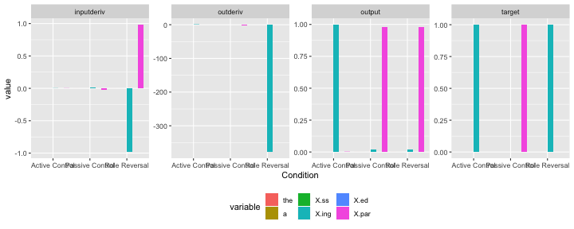

```r
showWordOutError("the,a,X.ss,X.ing,X.ed,X.par",c("Condition","measure"),postverb.df)
```

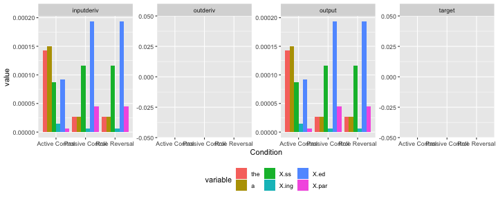

```r
showWordOutError("the,a,X.ss,X.ing,X.ed,X.par",c("Condition","measure"),verb.df)
```

```r
computeClozeERPCorr(postverb.df,dependMeasure,"word")
```

```
## [1] "Correlation output prediction and abssum error of word is -0.999999999999961"
```

```r
computeClozeERPCorr(postverb.df,dependMeasure,"hidden")
```

```
## [1] "Correlation output prediction and abssum error of hidden is -0.894997273980858"
```

```r
corrHiddenOutputInputDeriv(postverb.df,"Condition")
```

```
## Condition
##  Active Control Passive Control   Role Reversal
##               8               8               8
```

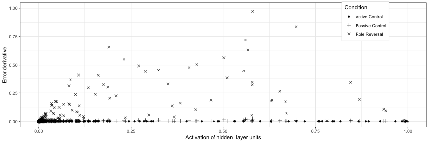

```r
#mapping = aes_string(x="depth", y="value", colour = "Condition",linetype="Condition")
norawpostverbnotargout.df=removeWordsDrawERP(postverb.df,"value","Condition")
```

```
##   sub  epoch word wordcat contfunc                              Example
## 1  s0 100000 -par     PAR        F  the tea is sip -par by a friend . .
## 2  s0 100000 -par     PAR        F  the tea is sip -par by a friend . .
## 3  s0 100000 -par     PAR        F  the tea is sip -par by a friend . .
## 4  s0 100000 -par     PAR        F  the tea is sip -par by a friend . .
## 5  s0 100000 -par     PAR        F  the tea is sip -par by a friend . .
## 6  s0 100000 -par     PAR        F  the tea is sip -par by a friend . .
##         Condition tick    layer    measure depth variable     value
## 1 Passive Control    5     word   outderiv     1   abssum 1.0241180
## 2 Passive Control    5     word inputderiv     1   abssum 0.0470991
## 3 Passive Control    5 compress   outderiv     2   abssum 1.4531393
## 4 Passive Control    5 compress inputderiv     2   abssum 0.0880563
## 5 Passive Control    5   hidden   outderiv     3   abssum 1.8791545
## 6 Passive Control    5   hidden inputderiv     3   abssum 0.1314669
```

```r
norawverbnotargout.df=removeWordsDrawERP(verb.df,"value","Condition")
```

```
##   sub  epoch word wordcat contfunc                              Example
## 1  s0 100000  sip   VERBT        C  the tea is sip -par by a friend . .
## 2  s0 100000  sip   VERBT        C  the tea is sip -par by a friend . .
## 3  s0 100000  sip   VERBT        C  the tea is sip -par by a friend . .
## 4  s0 100000  sip   VERBT        C  the tea is sip -par by a friend . .
## 5  s0 100000  sip   VERBT        C  the tea is sip -par by a friend . .
## 6  s0 100000  sip   VERBT        C  the tea is sip -par by a friend . .
##         Condition tick    layer    measure depth variable     value
## 1 Passive Control    4     word   outderiv     1   abssum 21.320910
## 2 Passive Control    4     word inputderiv     1   abssum  1.906195
## 3 Passive Control    4 compress   outderiv     2   abssum 24.644402
## 4 Passive Control    4 compress inputderiv     2   abssum  0.634280
## 5 Passive Control    4   hidden   outderiv     3   abssum 18.218561
## 6 Passive Control    4   hidden inputderiv     3   abssum  1.124015
```

```r
interactionText="NO TEXT"
modellist2 = list()
#norawpostverbnotargout.df=subset(norawpostverbnotargout.df,Condition != "No Attractor")
#norawpostverbnotargout.df=norawpostverbnotargout.df

# get example for table
semP6exampleword = subset(norawpostverbnotargout.df,measure == mainMeasure  & layer == "word")
exampleTable = semP6exampleword[1:12,c("Condition","Example")]
tabletext = kable(exampleTable,format="latex",row.names=FALSE)
print(exampleTable)
```

```
##              Condition                                   Example
## 114533 Passive Control       the tea is sip -par by a friend . .
## 114663  Active Control          the friend is sip -ing a tea . .
## 114780   Role Reversal          the tea is sip -ing a friend . .
## 116379 Passive Control    a wine is drink -par by the driver . .
## 116509  Active Control       a driver is drink -ing the wine . .
## 116626   Role Reversal       a wine is drink -ing the driver . .
## 117315 Passive Control  the water is drink -par by the clerk . .
## 117445  Active Control     the clerk is drink -ing the water . .
## 117562   Role Reversal     the water is drink -ing the clerk . .
## 117939 Passive Control       a tea is taste -par by the aunt . .
## 118069  Active Control          a aunt is taste -ing the tea . .
## 118186   Role Reversal          a tea is taste -ing the aunt . .
```

```r
semP6input  = subset(norawpostverbnotargout.df,measure == mainMeasure & layer %in% c("word",p600layer) )
semP6inputverb  = subset(norawverbnotargout.df,measure == mainMeasure & layer %in% c("word",p600layer) )

if (nlevels(adultdata.df$sub) > 4){ # do mixed with more than 9 subj

  options(contrasts=c("contr.treatment", "contr.treatment"))
#  semP6input$Condition = factor(semP6input$Condition,levels=c("Active Control", "Passive Control", "No Attractor", "Semantic Attractor"))
  semP6input$cpassive = 0
  semP6input$cpassive[semP6input$Condition=="Passive Control"]= 0.5
  semP6input$cpassive[semP6input$Condition=="Active Control"]=  -0.5
  semP6input$semattvsgram = 0
  semP6input$semattvsgram[semP6input$Condition=="Role Reversal"] = 1
  semP6input$semattvsgram[semP6input$Condition%in% c("Passive Control","Active Control")] = -0.5
    semP6input$cp600layer = ifelse(semP6input$layer==p600layer,0.5,-0.5)

  # this is the main mixed model with centered variables
  randomeff = paste(" + (1 + cp600layer  |sub)") # Condition * layer
    if (noslopes){ randomeff = " + (1 | sub)"}
  formu = as.formula(paste(dependMeasure,"~   cp600layer*cpassive + cp600layer*semattvsgram ",randomeff))
  omnimodel = lmer(formu, semP6input,control=lmerControl(optimizer = "bobyqa",optCtrl=list(maxfun=50000)))
  print(summary(omnimodel))
  modellist2 = modelComparison(omnimodel) # create anova table

  maincond = anova(modellist2[[3]],modellist2[[5]])
  condlayer = anova(modellist2[[1]],modellist2[[3]])

    # this model is for posthocs
  semP6input$semattvsgramf = factor(semP6input$semattvsgram,labels=c("ActPas","RoleRev"))
  formu2 = as.formula(paste(dependMeasure,"~  layer*semattvsgramf",randomeff))
  omnimodelFactor = lmer(formu2, semP6input)
  #print(summary(omnimodelFactor))
  model.lsmobj <- lsmeans(omnimodelFactor, ~ semattvsgramf | layer)
  posthocs = summary(as.glht(pairs(model.lsmobj)))
  print(posthocs)
  interactionText = printInteraction(posthocs)
  difflexSemP6 =  abs(posthocs$`layer = word`$test$coefficients[[1]])
  avedifflex = difflex/5
  print(paste("Ratio of lexical sem P6 vs other P6",difflexSemP6/avedifflex))

}
```

```
## Linear mixed model fit by REML ['lmerMod']
## Formula: abssum ~ cp600layer * cpassive + cp600layer * semattvsgram +
##     (1 + cp600layer | sub)
##    Data: semP6input
## Control: lmerControl(optimizer = "bobyqa", optCtrl = list(maxfun = 50000))
##
## REML criterion at convergence: 4249.8
##
## Scaled residuals:
##     Min      1Q  Median      3Q     Max
## -4.1154 -0.1134 -0.0044  0.0453  6.0360
##
## Random effects:
##  Groups   Name        Variance Std.Dev. Corr
##  sub      (Intercept) 0.1400   0.3742
##           cp600layer  0.5585   0.7474   1.00
##  Residual             0.5998   0.7744
## Number of obs: 1800, groups:  sub, 10
##
## Fixed effects:
##                         Estimate Std. Error t value
## (Intercept)              1.30643    0.11974  10.911
## cp600layer               1.27596    0.23914   5.336
## cpassive                 0.06970    0.04471   1.559
## semattvsgram             2.52607    0.02581  97.855
## cp600layer:cpassive      0.07700    0.08942   0.861
## cp600layer:semattvsgram  2.45799    0.05163  47.609
##
## Correlation of Fixed Effects:
##             (Intr) cp600l cpassv smttvs cp600lyr:c
## cp600layer  0.977
## cpassive    0.000  0.000
## semattvsgrm 0.000  0.000  0.000
## cp600lyr:cp 0.000  0.000  0.000  0.000
## cp600lyr:sm 0.000  0.000  0.000  0.000  0.000
## [1] "remove . ~ . -  cp600layer:semattvsgram "
```

```
## refitting model(s) with ML (instead of REML)
```

```
## Data: semP6input
## Models:
## model2: abssum ~ cp600layer + cpassive + semattvsgram + (1 + cp600layer |
## model2:     sub) + cp600layer:cpassive
## model: abssum ~ cp600layer * cpassive + cp600layer * semattvsgram +
## model:     (1 + cp600layer | sub)
##        Df    AIC    BIC  logLik deviance  Chisq Chi Df Pr(>Chisq)
## model2  9 5711.6 5761.0 -2846.8   5693.6
## model  10 4246.3 4301.3 -2113.2   4226.3 1467.2      1  < 2.2e-16 ***
## ---
## Signif. codes:  0 '***' 0.001 '**' 0.01 '*' 0.05 '.' 0.1 ' ' 1
## [1] "########## Above comparison for  cp600layer:semattvsgram  *** "
## [1] "remove . ~ . -  cp600layer:cpassive "
```

```
## refitting model(s) with ML (instead of REML)
```

```
## Data: semP6input
## Models:
## model2: abssum ~ cp600layer + cpassive + semattvsgram + (1 + cp600layer |
## model2:     sub)
## model: abssum ~ cp600layer + cpassive + semattvsgram + (1 + cp600layer |
## model:     sub) + cp600layer:cpassive
##        Df    AIC    BIC  logLik deviance  Chisq Chi Df Pr(>Chisq)
## model2  8 5709.9 5753.8 -2846.9   5693.9
## model   9 5711.6 5761.0 -2846.8   5693.6 0.3276      1     0.5671
## [1] "########## Above comparison for  cp600layer:cpassive "
## [1] "remove . ~ . -  semattvsgram "
```

```
## refitting model(s) with ML (instead of REML)
```

```
## Data: semP6input
## Models:
## model2: abssum ~ cp600layer + cpassive + (1 + cp600layer | sub)
## model: abssum ~ cp600layer + cpassive + semattvsgram + (1 + cp600layer |
## model:     sub)
##        Df    AIC    BIC  logLik deviance Chisq Chi Df Pr(>Chisq)
## model2  7 7878.8 7917.3 -3932.4   7864.8
## model   8 5709.9 5753.8 -2846.9   5693.9  2171      1  < 2.2e-16 ***
## ---
## Signif. codes:  0 '***' 0.001 '**' 0.01 '*' 0.05 '.' 0.1 ' ' 1
## [1] "########## Above comparison for  semattvsgram  *** "
## [1] "remove . ~ . -  cpassive "
```

```
## refitting model(s) with ML (instead of REML)
```

```
## Data: semP6input
## Models:
## model2: abssum ~ cp600layer + (1 + cp600layer | sub)
## model: abssum ~ cp600layer + cpassive + (1 + cp600layer | sub)
##        Df    AIC    BIC  logLik deviance  Chisq Chi Df Pr(>Chisq)
## model2  6 7877.1 7910.1 -3932.6   7865.1
## model   7 7878.8 7917.3 -3932.4   7864.8 0.3191      1     0.5721
## [1] "########## Above comparison for  cpassive "
## [1] "remove . ~ . -  cp600layer "
```

```
## refitting model(s) with ML (instead of REML)
```

```
## Data: semP6input
## Models:
## model2: abssum ~ (1 + cp600layer | sub)
## model: abssum ~ cp600layer + (1 + cp600layer | sub)
##        Df    AIC    BIC  logLik deviance  Chisq Chi Df Pr(>Chisq)
## model2  5 7888.8 7916.3 -3939.4   7878.8
## model   6 7877.1 7910.1 -3932.6   7865.1 13.698      1  0.0002147 ***
## ---
## Signif. codes:  0 '***' 0.001 '**' 0.01 '*' 0.05 '.' 0.1 ' ' 1
## [1] "########## Above comparison for  cp600layer  *** "
```

```
## refitting model(s) with ML (instead of REML)
## refitting model(s) with ML (instead of REML)
```

```
## Note: df set to 1778
```

```
## $`layer = word`
##
##   Simultaneous Tests for General Linear Hypotheses
##
## Linear Hypotheses:
##                       Estimate Std. Error t value Pr(>|t|)
## ActPas - RoleRev == 0 -1.94561    0.05478  -35.52   <2e-16 ***
## ---
## Signif. codes:  0 '***' 0.001 '**' 0.01 '*' 0.05 '.' 0.1 ' ' 1
## (Adjusted p values reported -- single-step method)
##
##
## $`layer = hidden`
##
##   Simultaneous Tests for General Linear Hypotheses
##
## Linear Hypotheses:
##                       Estimate Std. Error t value Pr(>|t|)
## ActPas - RoleRev == 0 -5.63260    0.05478  -102.8   <2e-16 ***
## ---
## Signif. codes:  0 '***' 0.001 '**' 0.01 '*' 0.05 '.' 0.1 ' ' 1
## (Adjusted p values reported -- single-step method)
##
##
## [1] "Ratio of lexical sem P6 vs other P6 4.93299727995744"
```

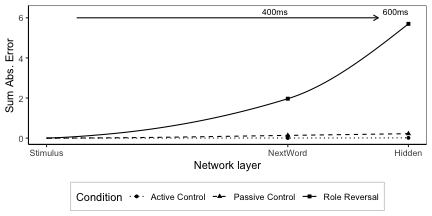

```r
  # figure for paper
semP6input[semP6input$Condition == "Passive Control",dependMeasure]=   0.1+semP6input[semP6input$Condition == "Passive Control",dependMeasure]
#   mapping = aes_string(x="depth", y=dependMeasure, colour = "Condition",linetype="Condition")
  p = drawERP(semP6input,dependMeasure,"Condition", timeline.y=6)
  p = p + scale_linetype_manual(values=c("dotted","dashed","solid")) #
  p
```

```r
  if (!noslopes){ # when doing final version, change noslopes to FALSE
    myggsave("img/semP6.png",width=figwidth,height=figheight)
  }
#   mapping = aes_string(x="depth", y=dependMeasure, colour = "Condition",linetype="Condition")
#  drawERP(semP6inputverb,mapping, timeline.y=6)

n4P6cor = computeN4P6correlation(semP6input)
print(paste("N400/P600 correlation",n4P6cor))
```

```
## [1] "N400/P600 correlation -0.893059986660004"
```

CUT AND PASTE INTO LATEX DOC click in box and use right arrow to see whole text

```latex
This is an example of the stimuli used in the model.


\begin{tabular}{l|l}
\hline
Condition & Example\\
\hline
Passive Control & the tea is sip -par by a friend . .\\
\hline
Active Control & the friend is sip -ing a tea . .\\
\hline
Role Reversal & the tea is sip -ing a friend . .\\
\hline
Passive Control & a wine is drink -par by the driver . .\\
\hline
Active Control & a driver is drink -ing the wine . .\\
\hline
Role Reversal & a wine is drink -ing the driver . .\\
\hline
Passive Control & the water is drink -par by the clerk . .\\
\hline
Active Control & the clerk is drink -ing the water . .\\
\hline
Role Reversal & the water is drink -ing the clerk . .\\
\hline
Passive Control & a tea is taste -par by the aunt . .\\
\hline
Active Control & a aunt is taste -ing the tea . .\\
\hline
Role Reversal & a tea is taste -ing the aunt . .\\
\hline
\end{tabular}
The maximal model for the data had random slopes  + (1 + cp600layer  |sub)
main effect $\chi^2$(2)=2171.27, p$<$0.001
interaction $\chi^2$(2)=1467.58, p$<$0.001

Mixed Model Results
a main effect of cp600layer ,$\beta$=1.3, SE=0.24, $\chi^2$(1)=13.7, p$<$0.001
no main effect of cpassive ,$\beta$=0.07, SE=0.045, $\chi^2$(1)=0.32, p=0.572
a main effect of semattvsgram ,$\beta$=2.5, SE=0.026, $\chi^2$(1)=2170.95, p$<$0.001
no interaction of cp600layer:cpassive ,$\beta$=0.077, SE=0.089, $\chi^2$(1)=0.33, p=0.567
@@an interaction of cp600layer:semattvsgram ,$\beta$=2.5, SE=0.052, $\chi^2$(1)=1467.25, p$<$0.001

Posthoc tests for  layer = word
 @@Posthoc: There was a significant difference for ActPas - RoleRev, diff = 1.9456, t(1778)=35.52, p$<$0.001
Posthoc tests for  layer = hidden
 @@Posthoc: There was a significant difference for ActPas - RoleRev, diff = 5.6326, t(1778)=102.82, p$<$0.001
ratio  ActPas - RoleRev   2.895  rev  0.345
```